# Chapter 13.4 - Non-centred priors

Fitting the model for chimps with two varying effects, one for block and one for actor.

```r
library(rethinking)
```

```r
data("chimpanzees")
d <- chimpanzees
d$treatment <- 1 + d$prosoc_left + 2*d$condition

dat_list <- list(
  pulled_left = d$pulled_left,
  actor=d$actor,
  block_id=d$block,
  treatment=as.integer(d$treatment)
)
set.seed(13)
m13.4 <- ulam(
  alist(
    pulled_left ~ dbinom( 1, p ),
    logit(p) <- a[actor] + g[block_id] + b[treatment],

    # Regular prior
    b[treatment] ~ dnorm( 0 , 0.5 ),

    ## adaptive priors
    a[actor] ~ dnorm(a_bar, sigma_a),
    g[block_id] ~ dnorm(0, sigma_g),

    ## hyper-priors
    a_bar ~ dnorm(0, 1.5),
    sigma_a ~ dexp(1),
    sigma_g ~ dexp(1)
  )
, data = dat_list, chains = 4 , log_lik = TRUE)
```

```r
precis(m13.4, depth=2)
```

|  | mean | sd | 5.5% | 94.5% | n_eff | Rhat4 |
| --- | --- | --- | --- | --- | --- | --- |
| b[1] | -0.10 | 0.31 | -0.60 | 0.37 | 512 | 1.00 |
| b[2] | 0.42 | 0.30 | -0.06 | 0.89 | 492 | 1.00 |
| b[3] | -0.45 | 0.30 | -0.94 | 0.03 | 564 | 1.00 |
| b[4] | 0.30 | 0.30 | -0.17 | 0.78 | 540 | 1.00 |
| a[1] | -0.39 | 0.37 | -0.97 | 0.21 | 426 | 1.01 |
| a[2] | 4.74 | 1.39 | 2.98 | 7.28 | 520 | 1.00 |
| a[3] | -0.69 | 0.36 | -1.27 | -0.10 | 513 | 1.00 |
| a[4] | -0.69 | 0.38 | -1.33 | -0.08 | 527 | 1.00 |
| a[5] | -0.39 | 0.36 | -0.96 | 0.20 | 502 | 1.00 |
| a[6] | 0.56 | 0.36 | 0.00 | 1.16 | 463 | 1.00 |

[output cut: 10 more lines]

We end up with divergent transitions. n_eff is quite low and rhat not always 1.00.

Divergent transition means that the particle in the simulation ended up with different energy at the end of its run than the start. Happens where the grad of the posterior is very steep in some region, can’t sample easily.

This is common, HMC is nice in that it gives us a warning, and it can be fixed by re-parameterising the model. That is, the model is mathematically the same, but numerically different.

#### 13.4.1 Devils funnel

```r
m13.7 <- ulam(
  alist(
    v ~ normal(0,3),
    x ~ normal(0,exp(v))
  ), data=list(N=1), chains=4
)
```

```r
precis(m13.7)
```

|  | mean | sd | 5.5% | 94.5% | n_eff | Rhat4 |
| --- | --- | --- | --- | --- | --- | --- |
| v | -0.42 | 1.93 | -2.75 | 3.12 | 7 | 1.36 |
| x | 0.22 | 7.23 | -3.89 | 4.95 | 375 | 1.01 |

n_eff is very very low and rhat=1.4

Happens cos as $v$ changes, $x$ changes a lot.

$x \sim \mathcal{N} (0, exp(v))$

Can change this numerically but keep it the same mathematically by moving the definition of the embedded parameter $v$ out of the definition of $x$.

$v \sim \mathcal{N} (0,3)$

$z \sim \mathcal{N} (0,1)$

$x = z \space exp(v)$

Substituting in gets us back to the same place that $x \sim \mathcal{N} (0, exp(v))$ had us in before. This is sort of like subtracting the mean and dividing by the standard deviation. Here we’ve started with the Normal (0,1) distribution and multuplied by exp(v), which is our standard deviation. If we had an awkward mean, we would add this back on here.

The trick is that now HMC samples from v and z, a lot easier! The $gq>$ bit below means generated quantity. It’s calculated at the end of every iteration, but not sampled from in the same way. Makes it easier.

```r
m13.7nc <- ulam(
  alist(
    v ~ normal(0,3),
    z ~ normal(0,1),
    gq> real[1]:x <<- z * exp(v)
  ), data=list(N=1), chains=4
)
precis(m13.7nc)
```

|  | mean | sd | 5.5% | 94.5% | n_eff | Rhat4 |
| --- | --- | --- | --- | --- | --- | --- |
| v | 0.02 | 2.92 | -4.70 | 4.54 | 1282 | 1 |
| z | 0.04 | 1.03 | -1.57 | 1.76 | 1126 | 1 |
| x | -5.84 | 1008.28 | -25.20 | 26.35 | 1696 | 1 |

A lot better now.

Now we know the trick, back to the chimps! Tricky distributions here are the adaptive priors.

$\alpha_j \sim \mathcal{N} (\bar{\alpha}, \sigma_\alpha)$

$\gamma_j \sim \mathcal{N} (0, \sigma_\gamma)$

That is $\bar{\alpha}, \sigma_\alpha, \sigma_\gamma$. We need to smuggle these into our linear model.

Same trick as before. Start with defining them as standardized variables in the code as `z[actor] ~ dnorm(0, 1)` and `x[block_id] ~ dnorm(0, 1)`

We then need to multiply these by their standard deviations $\sigma_\alpha$ and $\sigma_\gamma$ in the linear model. Here we have an akwakrd mean to add back in as well, $\bar{\alpha}$. All three variables are now smuggled into the linear model.

Treatment part and hyperparameters stay the same.

We want STAN to caculate these intercepts, as they’re of interest to us. Hence we put the generated quantities bit at the bottom.

```r
set.seed(13)
m13.4nc <- ulam(
  alist(
    pulled_left ~ dbinom( 1, p ),
    logit(p) <- a_bar + z[actor]*sigma_a + x[block_id]*sigma_g + b[treatment],

    # Regular prior
    b[treatment] ~ dnorm( 0 , 0.5 ),

    ## adaptive priors
    z[actor] ~ dnorm(0, 1),
    x[block_id] ~ dnorm(0, 1),

    ## hyper-priors
    a_bar ~ dnorm(0, 1.5),
    sigma_a ~ dexp(1),
    sigma_g ~ dexp(1),
    gq> vector[actor]:a <<- a_bar + z*sigma_a,
    gq> vector[block_id]:g <<- x*sigma_g
  )
, data = dat_list, chains = 4 , log_lik = TRUE)
precis(m13.4nc, depth=2)
```

|  | mean | sd | 5.5% | 94.5% | n_eff | Rhat4 |
| --- | --- | --- | --- | --- | --- | --- |
| b[1] | -0.13 | 0.29 | -0.59 | 0.34 | 1220 | 1.00 |
| b[2] | 0.40 | 0.29 | -0.07 | 0.85 | 1180 | 1.00 |
| b[3] | -0.48 | 0.31 | -0.97 | 0.01 | 1282 | 1.00 |
| b[4] | 0.28 | 0.30 | -0.19 | 0.78 | 1138 | 1.00 |
| z[1] | -0.55 | 0.38 | -1.16 | 0.03 | 409 | 1.00 |
| z[2] | 2.10 | 0.64 | 1.15 | 3.18 | 889 | 1.00 |
| z[3] | -0.70 | 0.39 | -1.34 | -0.10 | 447 | 1.00 |
| z[4] | -0.71 | 0.40 | -1.34 | -0.08 | 433 | 1.00 |
| z[5] | -0.54 | 0.38 | -1.14 | 0.05 | 459 | 1.00 |
| z[6] | -0.03 | 0.36 | -0.60 | 0.55 | 418 | 1.00 |

[output cut: 23 more lines]

And all of our n_effs are back near 500 or more, with only a few rhats not 1.00 and no warnings about divergent transitions.

Looking at the comparisons of n_eff

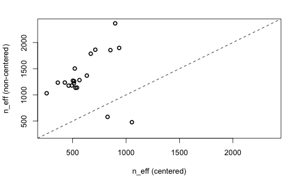

```r
precis_c <- precis( m13.4 , depth=2 )
precis_nc <- precis( m13.4nc , depth=2 )
pars <- c( paste("a[",1:7,"]",sep="") , paste("g[",1:6,"]",sep="") ,
paste("b[",1:4,"]",sep="") , "a_bar" , "sigma_a" , "sigma_g" )
neff_table <- cbind( precis_c[pars,"n_eff"] , precis_nc[pars,"n_eff"] )
plot( neff_table , xlim=range(neff_table) , ylim=range(neff_table) ,
xlab="n_eff (centered)" , ylab="n_eff (non-centered)" , lwd=2 )
abline( a=0 , b=1 , lty=2 )
```

All bar two of the parameters ($\bar{\alpha}$ and $\sigma_\gamma$) do better in terms of n_eff in our non-centred parametrisations.

We can do this with any distribution. E.g. $x = z\lambda$ and $z \sim Exponential(1)$ is the same as $x \sim Exponential(\lambda)$